# Arboles de decisión y bosques aleatorios

Para este notebook, usaremos el dataset “iris” que viene incluido en R, el cual usa Sepal.Length, Sepal.Width, Petal.Length y Petal.Width como predictores para la especie. Hay tres clases presentes en este dataset:

- Setosa
- Versicolor
- Virginica

```r
summary(iris)
```

```
  Sepal.Length    Sepal.Width     Petal.Length    Petal.Width          Species
 Min.   :4.300   Min.   :2.000   Min.   :1.000   Min.   :0.100   setosa    :50
 1st Qu.:5.100   1st Qu.:2.800   1st Qu.:1.600   1st Qu.:0.300   versicolor:50
 Median :5.800   Median :3.000   Median :4.350   Median :1.300   virginica :50
 Mean   :5.843   Mean   :3.057   Mean   :3.758   Mean   :1.199
 3rd Qu.:6.400   3rd Qu.:3.300   3rd Qu.:5.100   3rd Qu.:1.800
 Max.   :7.900   Max.   :4.400   Max.   :6.900   Max.   :2.500
```

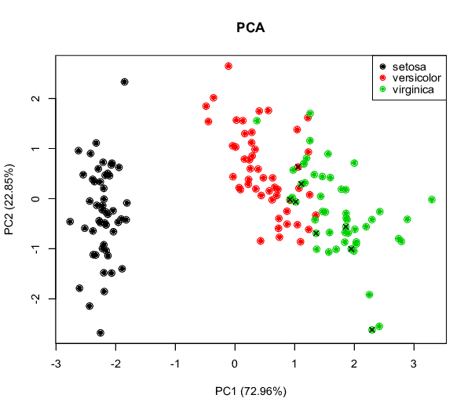

Mostraremos coomo construir un modelo predictivo con los paquetes party, rpart y randomForest. Los paquetes party y rpart se usan para construir arboles de decisión y el paquete randomForest para construir un bosque aleatorio

## Partir los datos

Partimos los datos en el conjunto de entrenamiento (70%) y de pruebas (30%)

```r
set.seed(1234) #Semilla
indices <- sample(2, nrow(iris), replace=TRUE, prob=c(0.7, 0.3))
conjunto_entrenamiento <- iris[indices==1,]
conjunto_prueba <- iris[indices==2,]
```

## Arboles de decisión con el paquete party

con la función ctree() del paquete party podemos construir un arbol de decisión y predict() predice la especie para futuras entradas.

### Entrenamiento

La función ctree() proporciona algunos parámetros, como MinSplit, MinBusket, MaxSurrogate y MaxDepth, para controlar el entrenamiento de los árboles de decisión. Nosotros usamos la configuración por defecto para construir el árbol de decisión.

En el siguiente código, formula especifica que **Species** es la variable objetivo y todas las demás variables son variables **independientes**.

```r
library(party)
formula <- Species ~ Sepal.Length + Sepal.Width + Petal.Length + Petal.Width
iris_ctree <- ctree(formula, data=conjunto_entrenamiento)
# Verificamos la predicción (notemos que lo hacemos con el conjunto de entrenamiento)
table(predict(iris_ctree), conjunto_entrenamiento$Species)
```

```
             setosa versicolor virginica
  setosa         40          0         0
  versicolor      0         37         3
  virginica       0          1        31
```

### Caracteristicas del modelo

Observemos las reglas

```r
print(iris_ctree)
```

```
     Conditional inference tree with 4 terminal nodes

Response:  Species
Inputs:  Sepal.Length, Sepal.Width, Petal.Length, Petal.Width
Number of observations:  112

1) Petal.Length <= 1.9; criterion = 1, statistic = 104.643
  2)*  weights = 40
1) Petal.Length > 1.9
  3) Petal.Width <= 1.7; criterion = 1, statistic = 48.939
    4) Petal.Length <= 4.4; criterion = 0.974, statistic = 7.397
      5)*  weights = 21
    4) Petal.Length > 4.4
      6)*  weights = 19
  3) Petal.Width > 1.7
    7)*  weights = 32
```

Observemos el arbol de decisión

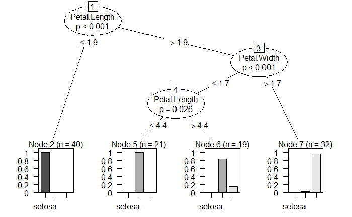

```r
#  Etiquetas de izquierda a derecha: Setosa, Versicolor, Virginica
plot(iris_ctree)
```

Otra forma…

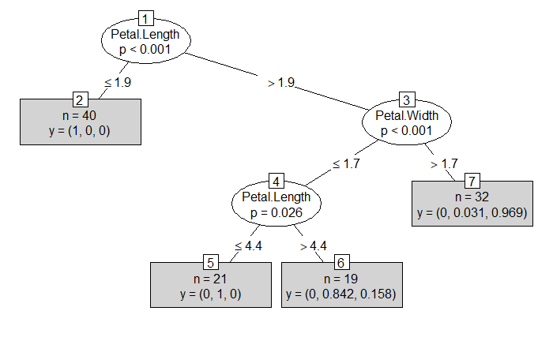

```r
plot(iris_ctree, type="simple")
```

la barra gris para cada nodo hoja muestra las probabilidades de que una instancia caiga en las tres especies. Se muestran como “y” en los nodos hoja. Por ejemplo, el nodo 2 está etiquetado con “n = 40, y = (1, 0, 0)”, lo que significa que contiene 40 instancias de entrenamiento y todas ellas pertenecen a la primera clase “setosa”

### Pruebas

Ahora probemos con el conjunto de pruebas:

```r
testPred_iris_ctree <- predict(iris_ctree, newdata = conjunto_prueba)
table(testPred_iris_ctree, conjunto_prueba$Species)
```

```
testPred_iris_ctree setosa versicolor virginica
         setosa         10          0         0
         versicolor      0         12         2
         virginica       0          0        14
```

La version acual de ctree() no maneja bien los datos faltantes, una instancia con datos faltantes aveces puede ir a la izquierda o derecha del arbol debido a las reglas de sustitución.

Otro problema es que, cuando existe una variable en los datos de entrenamiento y se introduce en ctree() pero no aparece en el árbol de decisión, los datos de prueba también deben tener esa variable para hacer la predicción. De lo contrario, una llamada a predict() fallaría.

## Arboles de decisión con el paquete rpart

### Entrenamiento

```r
library(rpart)
iris_rpart <- rpart(formula, data = conjunto_entrenamiento, control = rpart.control(minsplit = 10))
```

### Caracteristicas del modelo

```r
attributes(iris_rpart)
```

```
$names
 [1] "frame"               "where"               "call"                "terms"
 [5] "cptable"             "method"              "parms"               "control"
 [9] "functions"           "numresp"             "splits"              "variable.importance"
[13] "y"                   "ordered"

$xlevels
named list()

$ylevels
[1] "setosa"     "versicolor" "virginica"

$class
[1] "rpart"
```

```r
print(iris_rpart$cptable)
```

```
          CP nsplit  rel error     xerror       xstd
1 0.52777778      0 1.00000000 1.15277778 0.06438675
2 0.41666667      1 0.47222222 0.55555556 0.07042952
3 0.01388889      2 0.05555556 0.08333333 0.03309688
4 0.01000000      3 0.04166667 0.08333333 0.03309688
```

```r
print(iris_rpart)
```

```
n= 112

node), split, n, loss, yval, (yprob)
      * denotes terminal node

 1) root 112 72 setosa (0.35714286 0.33928571 0.30357143)
   2) Petal.Length< 2.45 40  0 setosa (1.00000000 0.00000000 0.00000000) *
   3) Petal.Length>=2.45 72 34 versicolor (0.00000000 0.52777778 0.47222222)
     6) Petal.Width< 1.75 40  3 versicolor (0.00000000 0.92500000 0.07500000)
      12) Petal.Length< 5.05 37  1 versicolor (0.00000000 0.97297297 0.02702703) *
      13) Petal.Length>=5.05 3  1 virginica (0.00000000 0.33333333 0.66666667) *
     7) Petal.Width>=1.75 32  1 virginica (0.00000000 0.03125000 0.96875000) *
```

Árbol de decisiones con paquete rpart

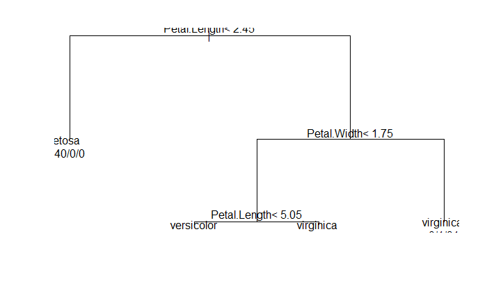

```r
plot(iris_rpart)
text(iris_rpart, use.n=T)
```

Luego seleccionamos el árbol con el mínimo error de predicción

```r
opt <- which.min(iris_rpart$cptable[,"xerror"])
cp <- iris_rpart$cptable[opt, "CP"]
iris_prune <- prune(iris_rpart, cp = cp)
print(iris_prune)
```

```
n= 112

node), split, n, loss, yval, (yprob)
      * denotes terminal node

1) root 112 72 setosa (0.3571429 0.3392857 0.3035714)
  2) Petal.Length< 2.45 40  0 setosa (1.0000000 0.0000000 0.0000000) *
  3) Petal.Length>=2.45 72 34 versicolor (0.0000000 0.5277778 0.4722222)
    6) Petal.Width< 1.75 40  3 versicolor (0.0000000 0.9250000 0.0750000) *
    7) Petal.Width>=1.75 32  1 virginica (0.0000000 0.0312500 0.9687500) *
```

Arbol de decisión optimo

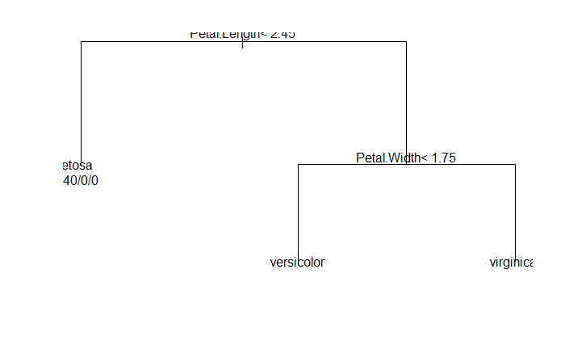

```r
plot(iris_prune)
text(iris_prune, use.n=T)
```

### Pruebas

el árbol seleccionado se usa para hacer la predicción y los valores predichos se comparan con las etiquetas reales.

```r
testPred_rpart <- predict(iris_prune, newdata = conjunto_prueba, type="class")
table(testPred_rpart, conjunto_prueba$Species)
```

```
testPred_rpart setosa versicolor virginica
    setosa         10          0         0
    versicolor      0         12         2
    virginica       0          0        14
```

## Bosques aleatorios

El paquete randomForest tambien lo usaremos para construir un modelo predictivo para el dataset iris.

### Entrenamiento

```r
library(randomForest)
rf <- randomForest(Species ~ ., data=conjunto_entrenamiento, ntree=100, proximity=TRUE)
table(predict(rf), conjunto_entrenamiento$Species)
```

```
             setosa versicolor virginica
  setosa         40          0         0
  versicolor      0         35         2
  virginica       0          3        32
```

### Caracteristicas del modelo

```r
print(rf)
```

```
Call:
 randomForest(formula = Species ~ ., data = conjunto_entrenamiento,      ntree = 100, proximity = TRUE)
               Type of random forest: classification
                     Number of trees: 100
No. of variables tried at each split: 2

        OOB estimate of  error rate: 4.46%
Confusion matrix:
           setosa versicolor virginica class.error
setosa         40          0         0  0.00000000
versicolor      0         35         3  0.07894737
virginica       0          2        32  0.05882353
```

```r
attributes(rf)
```

```
$names
 [1] "call"            "type"            "predicted"       "err.rate"        "confusion"
 [6] "votes"           "oob.times"       "classes"         "importance"      "importanceSD"
[11] "localImportance" "proximity"       "ntree"           "mtry"            "forest"
[16] "y"               "test"            "inbag"           "terms"

$class
[1] "randomForest.formula" "randomForest"
```

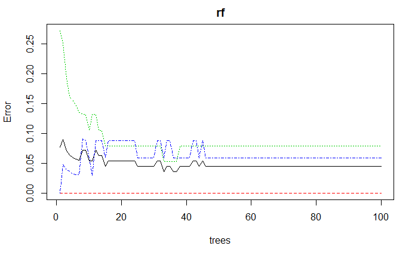

```r
# Tasa de error de Random Forest
plot(rf)
```

```r
importance(rf)
```

```
             MeanDecreaseGini
Sepal.Length         9.117125
Sepal.Width          1.975473
Petal.Length        29.854420
Petal.Width         32.911017
```

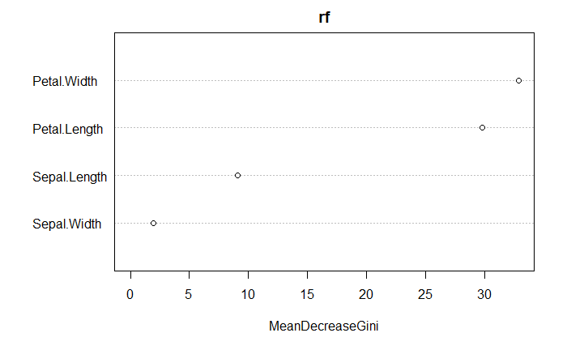

```r
varImpPlot(rf)
```

### Pruebas

```r
testPred_rf <- predict(rf, newdata=conjunto_prueba)
table(testPred_rf, conjunto_prueba$Species)
```

```
testPred_rf  setosa versicolor virginica
  setosa         10          0         0
  versicolor      0         12         2
  virginica       0          0        14
```

El margen de un punto de datos es la proporción de votos para la clase correcta menos la proporción máxima de votos para otras clases. En términos generales, un margen positivo significa una prediccion correcta.

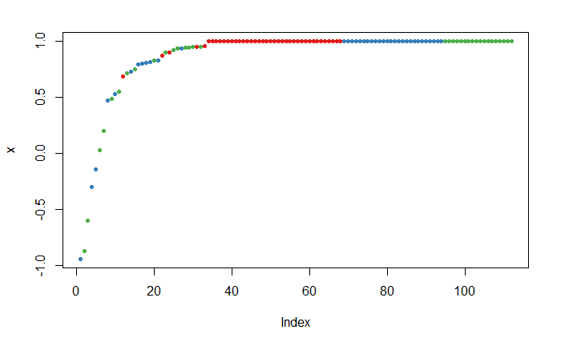

```r
plot(margin(rf, conjunto_prueba$Species))
```